# COMPSCIX 415.2 Homework 2

## **3.3.1 Exercises**

**1. What’s gone wrong with this code? Why are the points not blue?** `ggplot(data = mpg) + geom_point(mapping = aes(x = displ, y = hwy, color = "blue"))`

The points are not blue because setting ‘color’ to blue is setting the color manually to a fixed value for the *plot*. It does not use the *variables*. This needs to be set outside of `aes()` for the plot. You can set ‘color’ inside `aes()` if you are setting the color to map to a *variable*.

**2. Which variables in `mpg` are categorical? Which variables are continuous? (Hint: type ?mpg to read the documentation for the dataset). How can you see this information when you run `mpg`?**

```r
mpg
```

```
## # A tibble: 234 x 11
##    manufacturer model displ  year   cyl trans drv     cty   hwy fl    class
##    <chr>        <chr> <dbl> <int> <int> <chr> <chr> <int> <int> <chr> <chr>
##  1 audi         a4      1.8  1999     4 auto~ f        18    29 p     comp~
##  2 audi         a4      1.8  1999     4 manu~ f        21    29 p     comp~
##  3 audi         a4      2    2008     4 manu~ f        20    31 p     comp~
##  4 audi         a4      2    2008     4 auto~ f        21    30 p     comp~
##  5 audi         a4      2.8  1999     6 auto~ f        16    26 p     comp~
##  6 audi         a4      2.8  1999     6 manu~ f        18    26 p     comp~
##  7 audi         a4      3.1  2008     6 auto~ f        18    27 p     comp~
##  8 audi         a4 q~   1.8  1999     4 manu~ 4        18    26 p     comp~
##  9 audi         a4 q~   1.8  1999     4 auto~ 4        16    25 p     comp~
## 10 audi         a4 q~   2    2008     4 manu~ 4        20    28 p     comp~
## # ... with 224 more rows
```

Categorical: manufacturer, model, trans, drv, fl, class  
Continuous: displ, year, cyl, cty, hwy  
You can see this information by running `mpg` where the third row of the table shows each variable’s data type. *`<chr>`* (for characters) represents categorical; *`<dbl>`* (for doubles) and *`<int>`* (for integers) represent continuous.

**3. Map a continuous variable to `color`, `size`, and `shape`. How do these aesthetics behave differently for categorical vs. continuous variables?**

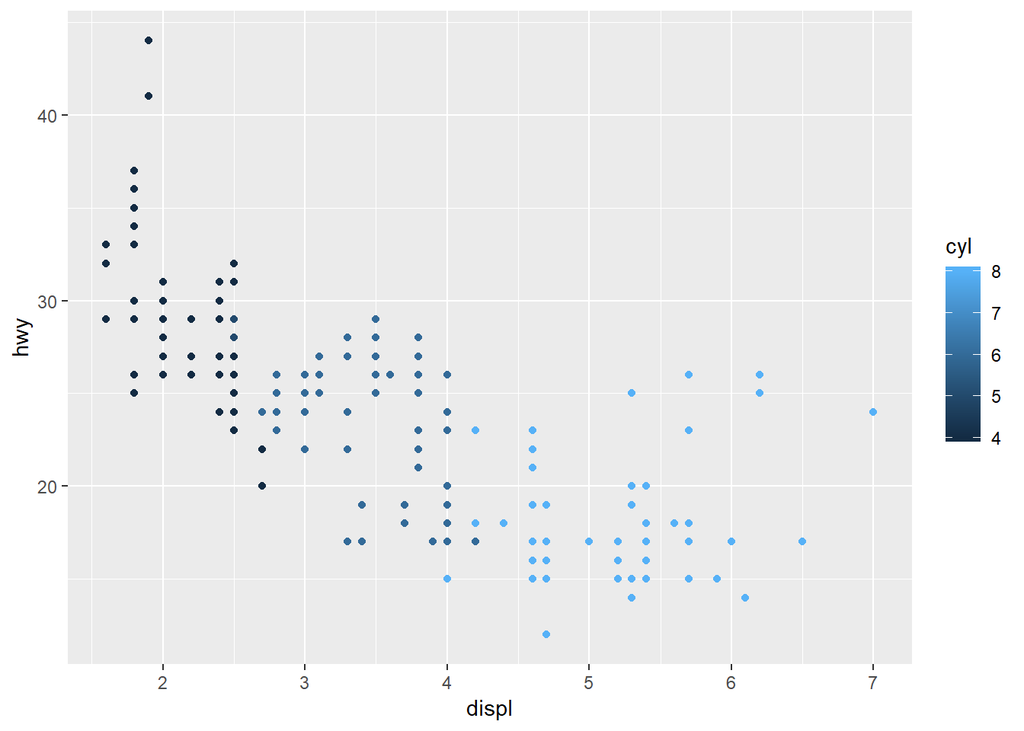

```r
mpgPlot + geom_point(aes(x = displ, y = hwy, color = cyl))
```

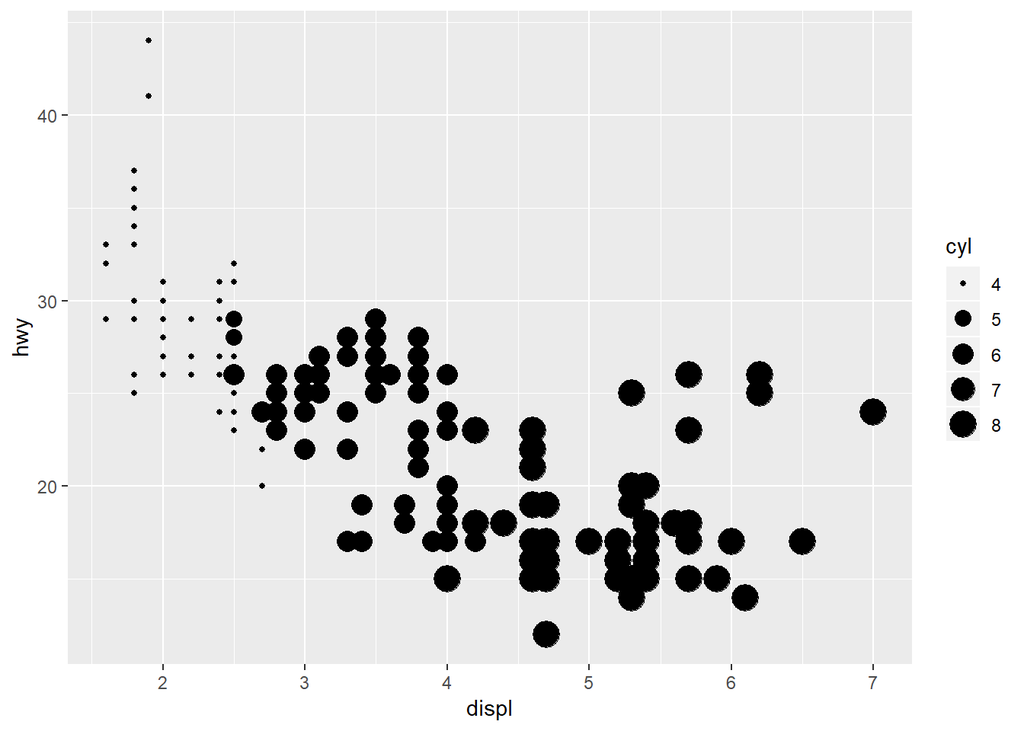

```r
mpgPlot + geom_point(aes(x = displ, y = hwy, size = cyl))
```

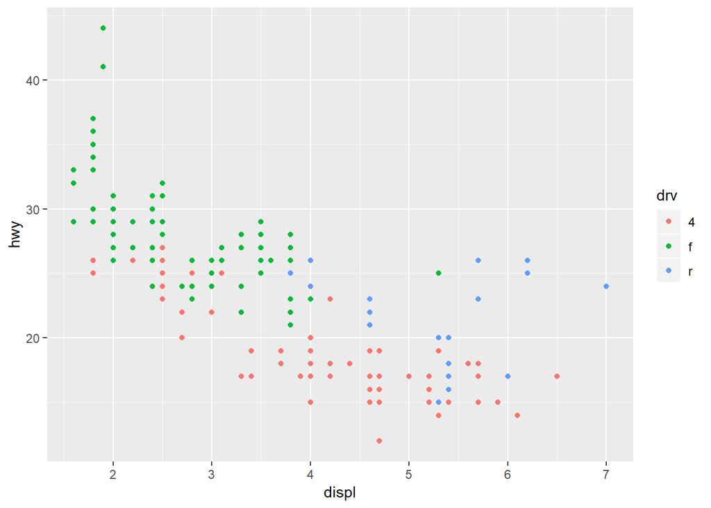

```r
mpgPlot + geom_point(aes(x = displ, y = hwy, color = drv))
```

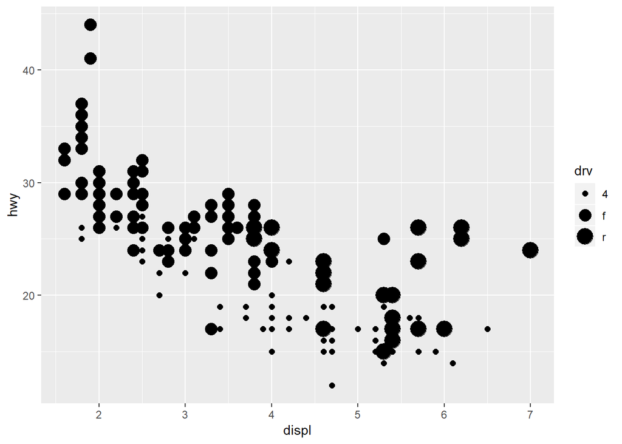

```r
mpgPlot + geom_point(aes(x = displ, y = hwy, size = drv))
```

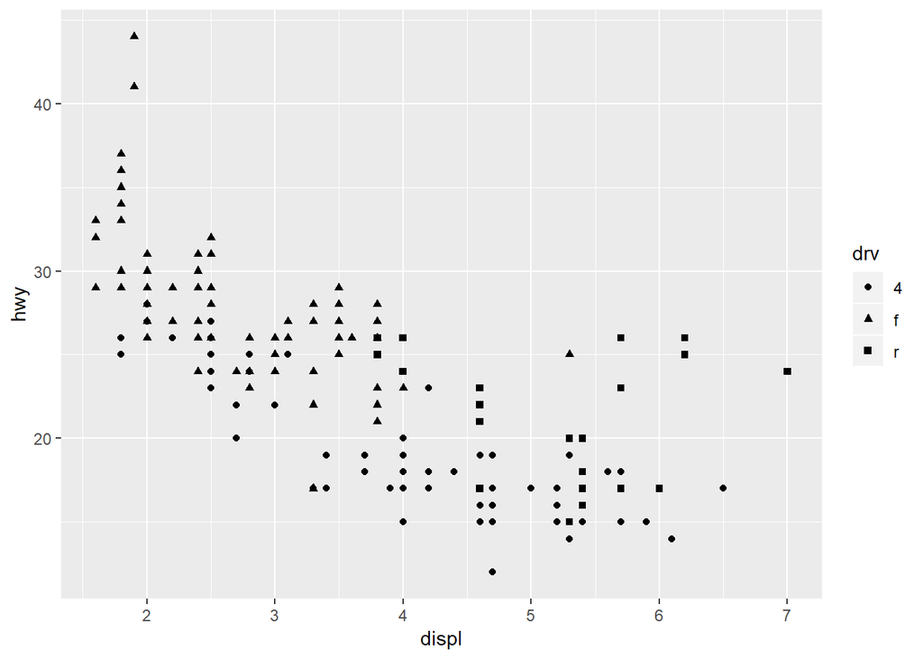

```r
mpgPlot + geom_point(aes(x = displ, y = hwy, shape = drv))
```

`shape` cannot be mapped to a continuous variable because of the limited number of shapes, but mapping `color` and `size` to a continuous variable creates a gradient for `color` and bins markers for `size`.

**4. What happens if you map the same variable to multiple aesthetics?**

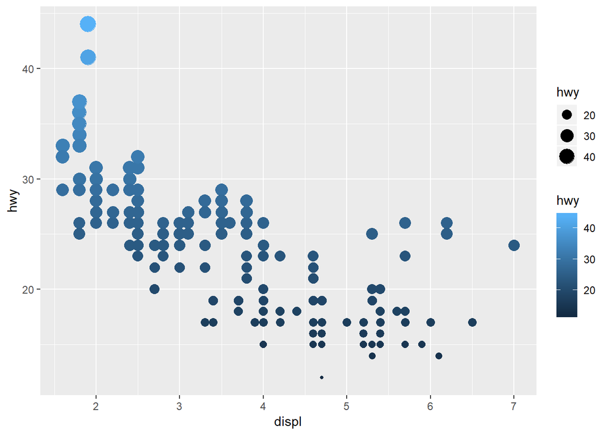

```r
mpgPlot + geom_point(aes(x = displ, y = hwy, color = hwy, size = hwy))
```

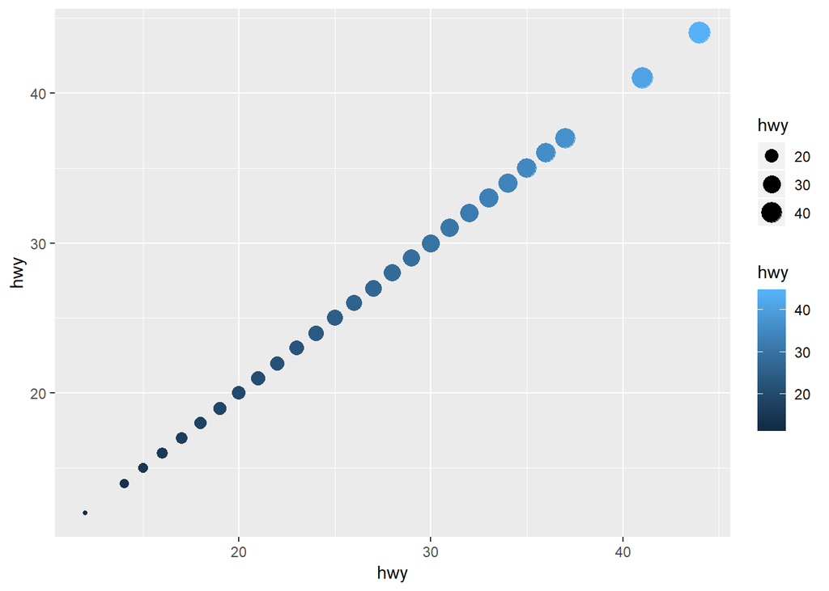

```r
mpgPlot + geom_point(aes(x = hwy, y = hwy, color = hwy, size = hwy))
```

Depending on the aesthetic parameter, the variable will just be displayed as mapped.  
If x and y are mapped to the same variable, the slope of the plot will be 1 with a linear trend.